# filtering mobile phone spam with the Naive Bayes algorithm

Mastan Rao Parimi

February 6, 2019

# exploring and preparing the data

```r
sms_raw <- read.csv("sms_spam.csv", stringsAsFactors = FALSE)
```

Summary

```r
str(sms_raw)
```

```
## 'data.frame':    5574 obs. of  2 variables:
##  $ type: chr  "ham" "ham" "spam" "ham" ...
##  $ text: chr  "Go until jurong point, crazy.. Available only in bugis n great world la e buffet... Cine there got amore wat..." "Ok lar... Joking wif u oni..." "Free entry in 2 a wkly comp to win FA Cup final tkts 21st May 2005. Text FA to 87121 to receive entry question("| __truncated__ "U dun s…
```

The type element is currently a character vector. Since this is a categorical variable, it would be better to convert it into a factor

```r
sms_raw$type <- factor(sms_raw$type)
```

Examining this with the str() and table() functions, we see that type has now been appropriately recoded as a factor.

```r
str(sms_raw)
```

```
## 'data.frame':    5574 obs. of  2 variables:
##  $ type: Factor w/ 2 levels "ham","spam": 1 1 2 1 1 2 1 1 2 2 ...
##  $ text: chr  "Go until jurong point, crazy.. Available only in bugis n great world la e buffet... Cine there got amore wat..." "Ok lar... Joking wif u oni..." "Free entry in 2 a wkly comp to win FA Cup final tkts 21st May 2005. Text FA to 87121 to receive entry question("| __truncated__ "U dun s…
```

```r
table(sms_raw$type)
```

```
##
##  ham spam
## 4827  747
```

# Data preparation – cleaning and standardizing text data

```r
library(tm)
```

The first step in processing text data involves creating a corpus, which is a collection of text documents.

```r
sms_corpus <- VCorpus(VectorSource(sms_raw$text))
```

```r
print(sms_corpus)
```

```
## <<VCorpus>>
## Metadata:  corpus specific: 0, document level (indexed): 0
## Content:  documents: 5574
```

we can use the inspect() function with list operators. For example, the following command will view a summary of the first and second SMS messages in the corpus:

```r
inspect(sms_corpus[1:2])
```

```
## <<VCorpus>>
## Metadata:  corpus specific: 0, document level (indexed): 0
## Content:  documents: 2
##
## [[1]]
## <<PlainTextDocument>>
## Metadata:  7
## Content:  chars: 111
##
## [[2]]
## <<PlainTextDocument>>
## Metadata:  7
## Content:  chars: 29
```

To view the actual message text, the as.character() function must be applied to the desired messages.

```r
as.character(sms_corpus[[1]])
```

```
## [1] "Go until jurong point, crazy.. Available only in bugis n great world la e buffet... Cine there got amore wat..."
```

The tm_map() function provides a method to apply a transformation (also known as mapping) to a tm corpus. We will use this function to clean up our corpus using a series of transformations and save the result in a new object called corpus_clean.

```r
sms_corpus_clean <- tm_map(sms_corpus,
content_transformer(tolower))
```

Let’s continue our cleanup by removing numbers from the SMS messages.

```r
sms_corpus_clean <- tm_map(sms_corpus_clean, removeNumbers)
```

Our next task is to remove filler words such as to, and, but, and or from our SMS messages. These terms are known as stop words and are typically removed prior to text mining. This is due to the fact that although they appear very frequently, they do not provide much useful information for machine learning.

```r
sms_corpus_clean <- tm_map(sms_corpus_clean,
removeWords, stopwords())
```

Continuing with our cleanup process, we can also eliminate any punctuation from the text messages using the built-in removePunctuation() transformation:

```r
sms_corpus_clean <- tm_map(sms_corpus_clean, removePunctuation)
```

In order to apply the wordStem() function to an entire corpus of text documents, the tm package includes a stemDocument() transformation. We apply this to our corpus with the tm_map() function exactly as done earlier:

```r
library(SnowballC)
sms_corpus_clean <- tm_map(sms_corpus_clean, stemDocument)
```

After removing numbers, stop words, and punctuation as well as performing stemming, the text messages are left with the blank spaces that previously separated the now-missing pieces. The final step in our text cleanup process is to remove additional whitespace, using the built-in stripWhitespace()  
transformation:

```r
sms_corpus_clean <- tm_map(sms_corpus_clean, stripWhitespace)
```

# Data preparation – splitting text documents into words

Creating a DTM sparse matrix, given a tm corpus, involves a single command:

```r
sms_dtm <- DocumentTermMatrix(sms_corpus_clean)
```

On the other hand, if we hadn’t performed the preprocessing, we could do so here by providing a list of control parameter options to override the defaults. For example, to create a DTM directly from the raw, unprocessed SMS corpus, we can use the following command:

```r
sms_dtm2 <- DocumentTermMatrix(sms_corpus, control = list(
tolower = TRUE,
removeNumbers = TRUE,
stopwords = TRUE,
removePunctuation = TRUE,
stemming = TRUE
))
```

# Data preparation – creating training and test datasets

```r
set.seed(45)
sample_items  <- sample.int(n=nrow(sms_dtm),
                            size = floor(.75*nrow(sms_dtm)),
                            replace = FALSE)
sms_dtm_train <- sms_dtm[sample_items, ]
sms_dtm_test <- sms_dtm[-sample_items, ]
sms_train_labels <- sms_raw[sample_items, ]$type
sms_test_labels <- sms_raw[-sample_items, ]$type
```

To confirm that the subsets are representative of the complete set of SMS data, let’s compare the proportion of spam in the training and test data frames:

```r
prop.table(table(sms_train_labels))
```

```
## sms_train_labels
##       ham      spam
## 0.8636364 0.1363636
```

```r
prop.table(table(sms_test_labels))
```

```
## sms_test_labels
##       ham      spam
## 0.8730273 0.1269727
```

# Visualizing text data – word clouds

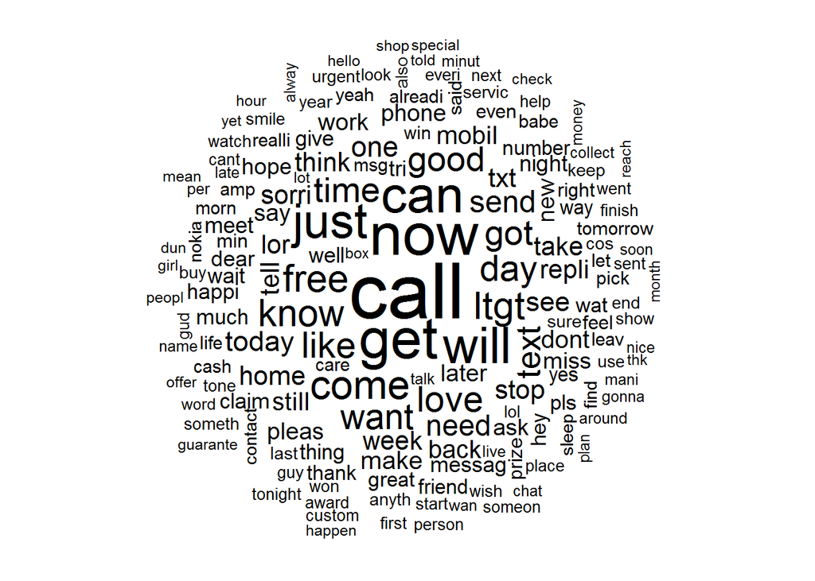

```r
library(wordcloud)
wordcloud(sms_corpus_clean, min.freq = 50, random.order = FALSE)
```

Let’s use R’s subset() function to take a subset of the sms_raw data by the SMS type. First, we’ll create a subset where the message type is spam:

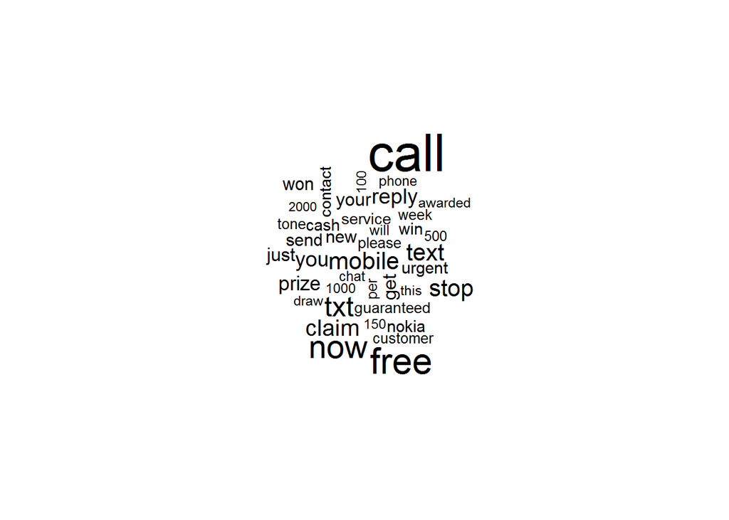

```r
spam <- subset(sms_raw, type == "spam")
ham <- subset(sms_raw, type == "ham")
wordcloud(spam$text, max.words = 40, scale = c(3, 0.5))
```

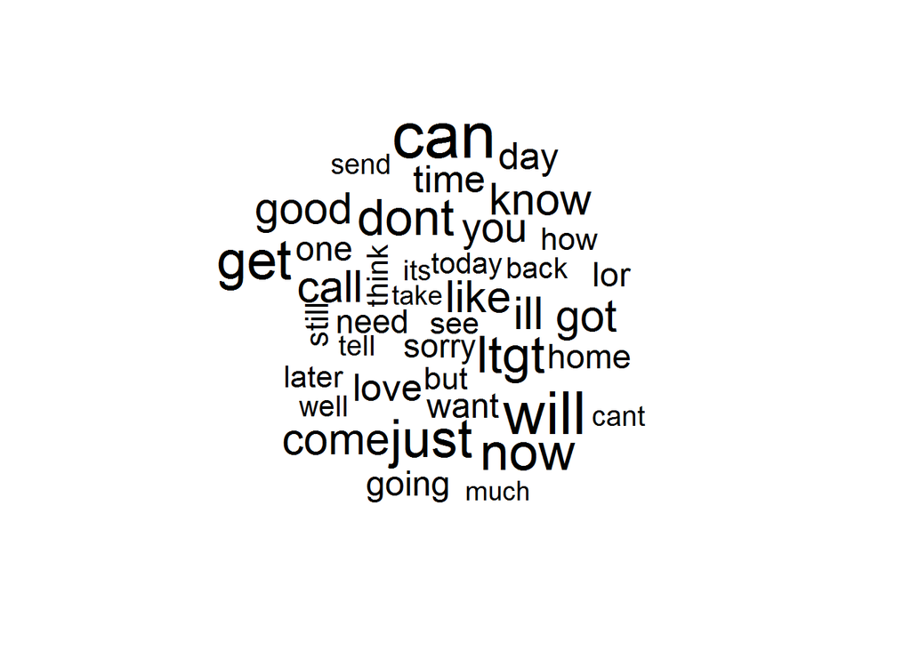

```r
wordcloud(ham$text, max.words = 40, scale = c(3, 0.5))
```

```r
sms_freq_words <- findFreqTerms(sms_dtm_train, 5)
```

```r
str(sms_freq_words)
```

```
##  chr [1:1159] "â€¦" "â€“" "abiola" "abl" "abt" "accept" "access" ...
```

We now need to filter our DTM to include only the terms appearing in a specified vector.

```r
sms_dtm_freq_train<- sms_dtm_train[ , sms_freq_words]
sms_dtm_freq_test <- sms_dtm_test[ , sms_freq_words]
```

```r
convert_counts <- function(x) {
x <- ifelse(x > 0, "Yes", "No")
}
sms_train <- apply(sms_dtm_freq_train, MARGIN = 2, convert_counts)
sms_test <- apply(sms_dtm_freq_test, MARGIN = 2, convert_counts)
```

# training a model on the data

The Naive Bayes implementation we will employ is in the e1071 package.

```r
library(e1071)
```

To build our model on the sms_train matrix, we’ll use the following command:

```r
sms_classifier <- naiveBayes(sms_train, sms_train_labels)
```

# evaluating model performance

The predict() function is used to make the predictions.

```r
sms_test_pred <- predict(sms_classifier, sms_test)
```

To compare the predictions to the true values, we’ll use the CrossTable()

```r
library(gmodels)
CrossTable(sms_test_pred, sms_test_labels, prop.chisq = FALSE, prop.t = FALSE,
dnn = c('predicted', 'actual'))
```

```
##
##
##    Cell Contents
## |-------------------------|
## |                       N |
## |           N / Row Total |
## |           N / Col Total |
## |-------------------------|
##
##
## Total Observations in Table:  1394
##
##
##              | actual
##    predicted |       ham |      spam | Row Total |
## -------------|-----------|-----------|-----------|
##          ham |      1209 |        21 |      1230 |
##              |     0.983 |     0.017 |     0.882 |
##              |     0.993 |     0.119 |           |
## -------------|-----------|-----------|-----------|
##         spam |         8 |       156 |       164 |
##              |     0.049 |     0.951 |     0.118 |
##              |     0.007 |     0.881 |           |
## -------------|-----------|-----------|-----------|
## Column Total |      1217 |       177 |      1394 |
##              |     0.873 |     0.127 |           |
## -------------|-----------|-----------|-----------|
##
##
```

# improving model performance

We’ll build a Naive Bayes model as done earlier, but this time set laplace = 1:

```r
sms_classifier2 <- naiveBayes(sms_train, sms_train_labels,
laplace = 1)
```

Next, we’ll make predictions:

```r
sms_test_pred2 <- predict(sms_classifier2, sms_test)
```

compare the predicted classes to the actual classifications using a cross tabulation:

```r
CrossTable(sms_test_pred2, sms_test_labels,
prop.chisq = FALSE, prop.t = FALSE, prop.r = FALSE,
dnn = c('predicted', 'actual'))
```

```
##
##
##    Cell Contents
## |-------------------------|
## |                       N |
## |           N / Col Total |
## |-------------------------|
##
##
## Total Observations in Table:  1394
##
##
##              | actual
##    predicted |       ham |      spam | Row Total |
## -------------|-----------|-----------|-----------|
##          ham |      1210 |        26 |      1236 |
##              |     0.994 |     0.147 |           |
## -------------|-----------|-----------|-----------|
##         spam |         7 |       151 |       158 |
##              |     0.006 |     0.853 |           |
## -------------|-----------|-----------|-----------|
## Column Total |      1217 |       177 |      1394 |
##              |     0.873 |     0.127 |           |
## -------------|-----------|-----------|-----------|
##
##
```